# XGBOOST

[figure not shown]

## Workflow stages:

1. Goals and final targets definition
2. Data preparation for modeling, various models and encoding technique analysis
   - Features with NaN values analysis
   - Dealing with categorical features
   - Cross validation strategy
   - Various models and encoding technique analysis
   - Final panel preparation for the model
3. Models comparison
   - Models evaluation prior implementing a cross validation: Accuracy and log loss
   - Models evaluation using a cross validation: Accuracy, Log loss, Recall, Precision, F-score and AUC
4. Learning Curves:
   - Train data errors vs Cross validation errors
   - Accuracy vs Number of trees and max depth
5. Explore the model in order to improve the results:
   - Hyperparameters tuning and optimization
   - Early stop strategy
6. Confusion matrix and threshhold tuning
7. Effort to improve the results-Stacking implementation
1. Chapter 1 - Goals and final targets definition
2. Chapter 2 - Data preparation for modeling, various models and encoding technique analysis
3. Chapter 3 - Models comparison
4. Chapter 4 - Learning Curves
5. Chapter 5 - Explore the model to improve the results
6. Chapter 6 - Confusion matrix and threshhold tuning
7. Chapter 7 - Effort to improve the results-Stacking implementation

## * Importing required libraries

```python
from sklearn import datasets, linear_model, metrics, model_selection, tree, ensemble
from sklearn import preprocessing
from xgboost.sklearn import XGBClassifier, XGBRegressor
from sklearn.linear_model import Ridge
from sklearn.ensemble import RandomForestRegressor
from sklearn.linear_model import LogisticRegression
from sklearn.model_selection import GridSearchCV
import pandas as pd
import numpy as np
from mlxtend.classifier import StackingClassifier
import scipy
import itertools
import matplotlib.pyplot as plt
from scipy.sparse import csr_matrix
from scipy.sparse import coo_matrix, hstack
import xgboost as xgb
from xgboost import plot_importance
from xgboost import plot_tree
from catboost import CatBoostClassifier, Pool
from patsy import dmatrix
from IPython.display import display
from statsmodels.stats.weightstats import DescrStatsW
import warnings
warnings.filterwarnings("ignore")
%pylab inline

root = 'C:/Users/Alex/Desktop/Learning/XGBOOST competition/XGboost/Course competition/xgboostlab updated/'
pd.set_option('display.max_rows', 500)
pd.set_option('display.max_columns', 500)
```

## 1) Goals and final targets definition

#### The goal is to build models for predicting the following:

1. Predict labour force participation (LFP): Predict wether people participated in the survey will be a part of the working force in year 2017 based on 2013 data.
2. Predict decile income group improvement: Predict if the survey participants improved theirincome group in 2017 based on 2013 data.
3. Predicting Hourly Income for those who worked: Participants hour income in year 2017 based on 2013 data.

## 2) Data preparation for modeling, various models and encoding technique analysis - Predict labour force participation (LFP)

```python
"Variables definition"

# Variables for train/test split:
seed=30  # Random numbers seed
test_size=0.3  # Test size

# Variables for features engineering:
null_features_proportion=0.9  # The proportion of features with NaN values
data_len=0  # The data size (number of rows)
features_count=1  # The total number of columns (number of all features)
index_column=1  # Selecting rows/columns reference in pandas drop function

# Variables for model parameters:
folds=5  # Number of folds in the cross validation
activated=True  # Is a shufle method is performed in a cross validation
num_of_trees=100  # Number of trees in the model
tree_depth=5  # Tree depth
```

```python
def load_data_LFP():
    "Function loads and prepares the data for modeling and returns data in pandas dataframe format"

    # Load the data from the defined directory:
    dflearning = pd.read_csv(root + 'dflearning.csv')

    # Preparing the data for the model:
    drops = ['id','wave','misparprat','siduri','misparmeshivproxy','mishkalorech','nGroup','n','future_hour_income',
            'incomeGroupUp','incomeGroupDown','s_seker','futereLFP','gilGroup','paamachronachashavani','futureIncomeGroup',
            'gilm','future_mean_income_group','Unnamed: 0']
    dflearning = dflearning.sample(frac=1)
    dflearning = dflearning.replace(np.Inf, np.nan)
    dflearning = dflearning.query('incomeGroup<10')
    data=dflearning.drop(drops,axis=index_column)

    # Defining the target variable:
    YLFP = dflearning['futereLFP']

    return data, YLFP
```

```python
# Calling data_load function:
data, YLFP=load_data_LFP()
```

```python
data.shape
```

```
(4526, 159)
```

### 2.1) Features with NaN values analysis

```python
# Checking whether there are features with NaN values:

# Features where all the data is NaN:
Null_features_all=[features for features in data.columns if data[features].isnull().sum()==data.shape[data_len]]

# Features with more than 90% of NaN values:
Null_features_part=[features for features in data.columns
                    if (data[features].isnull().sum()/data.shape[data_len]>null_features_proportion)]
```

```python
print ("The number of features without any data is:", len(Null_features_all))
print ("The number of features with more than 90% of NaN data is:", len(Null_features_part))
```

```
The number of features without any data is: 26
The number of features with more than 90% of NaN data is: 45
```

After checking the accuracy results of each model it was decided to drop the unnecessary data (Columns where all the data is Null and columns where at least 90% of data is Null).

```python
# Drop columns with features were more than 90% of data is Null:
data=data.drop(Null_features_part ,axis=index_column)
```

```python
# An updated data size:
data.shape
```

```
(4526, 114)
```

### 2.2) Dealing with categorical features

```python
def check_categorical_features (data, counter=0):
    "Function calculates the proportion of categorical features from all the features in the dataset and prints the result"

    for col in data.columns:
        if data[col].dtypes=='object':
            counter+=1
    print("The percentage of the categorical features from the total number of features is:",
          round(counter/data.shape[features_count], 3)*100,'%')
```

```python
check_categorical_features(data)
```

```
The percentage of the categorical features from the total number of features is: 65.8 %
```

Taking in the consideration the fact that the ratio of categorical features is above 50% , it was decided to try different categorical features engineering technique and encoding for our final panel preparation in order to try improving models results:

1. One Hot Encoding
2. Mean target values
3. Using Catboost library

### 2.3) Cross validation strategy

```python
# Check the classes proportion:
round(YLFP.value_counts(normalize=True),2)
```

```
True     0.61
False    0.39
Name: futereLFP, dtype: float64
```

[figure not shown]

```python
# Cross validation strategy:
skf = model_selection.StratifiedKFold(n_splits=folds, shuffle=activated)
```

```python
# Defining the estimator for the model:
xgboost = XGBClassifier(max_depth=tree_depth, n_estimators=num_of_trees, random_state=seed)
```

### 2.4) Various models and encoding technique analysis

In order to compare the results of each aforementioned categorical features techniques (See chapter 2.2 above - "Dealing with categorical features") it was decided to define model without any categorical features as a baseline result

```python
def compare_encoding_techniques(data, YLFP, test_size, seed):
    "Function calculates the accuracy on the cross validation and test data and prints the results"

    "Data without categorical features"
    X1=data.loc[:, data.dtypes != 'object']

    # Spliting data to train and test data:
    X_train1, X_test1, y_train1, y_test1 = model_selection.train_test_split(X1, YLFP, test_size=test_size,random_state=seed)

    # Accuracy on cross validation:
    print("Data with no categorical features - Accuracy on the cross validation is:",
    round(np.mean(model_selection.cross_val_score(xgboost, X_train1, y_train1, cv=skf, scoring='accuracy')), 4))

    # Fit the model on the train data:
    model1=xgboost.fit(X_train1, y_train1)

    # Accuracy on test data:
    print("Data with no categorical features - Accuracy on test data is:",
    round (metrics.accuracy_score(y_test1, model1.predict(X_test1)),4))
    print("-------------------------------------------------------------------------------")


    "One Hot encoding"
    cols = list(data.select_dtypes(include=['object']).columns)
    X2 = pd.get_dummies(data=data, columns=cols,sparse=True)

    # Spliting data to train and test for the model:
    X_train, X_test, y_train, y_test = model_selection.train_test_split(np.array(X2), YLFP, test_size=test_size,
                                                                        random_state=seed)
    # Accuracy on cross validation:
    print("One Hot Encoding - Accuracy on the cross validation is:",
    round(np.mean(model_selection.cross_val_score(xgboost, X_train, y_train, cv=skf, scoring='accuracy')),4))

    # Fit the model on the train data:
    model2=xgboost.fit(X_train, y_train)

    # Accuracy on test data:
    print("One Hot Encoding - Accuracy on test data is:",
    round (metrics.accuracy_score(y_test, model2.predict(X_test)),4))
    print("-------------------------------------------------------------------------------")


    "Mean target technique"
    X=data
    train_df_part, valid_df, y_train_part, y_valid = model_selection.train_test_split(X, YLFP, test_size=test_size,
                                                                                  random_state=seed)

    "Function calculates a mean for every category of categorical feature using a cross validation"
    def mean_target_enc(train_df, y_train, valid_df):
        glob_mean = y_train.mean()
        train_df = pd.concat([train_df, pd.Series(y_train, name='y')], axis=1)
        new_train_df = train_df.copy()

        cat_features = train_df.columns[train_df.dtypes == 'object'].tolist()

        for col in cat_features:
            new_train_df[col + '_mean_target'] = [glob_mean for _ in range(new_train_df.shape[0])]

        for train_idx, valid_idx in skf.split(train_df, y_train):
            train_df_cv, valid_df_cv = train_df.iloc[train_idx, :], train_df.iloc[valid_idx, :]

            for col in cat_features:
                means = valid_df_cv[col].map(train_df_cv.groupby(col)['y'].mean())
                valid_df_cv[col + '_mean_target'] = means.fillna(glob_mean)

            new_train_df.iloc[valid_idx] = valid_df_cv

        new_train_df.drop(cat_features + ['y'], axis=1, inplace=True)

        for col in cat_features:
            means = valid_df[col].map(train_df.groupby(col)['y'].mean())
            valid_df[col + '_mean_target'] = means.fillna(glob_mean)

        valid_df.drop(train_df.columns[train_df.dtypes == 'object'], axis=index_column, inplace=True)

        return new_train_df, valid_df

    train_mean_target_part, valid_mean_target = mean_target_enc(train_df_part, y_train_part, valid_df)

    # Accuracy on cross validation:
    print("Mean target Encoding - Accuracy on the cross validation is:",
    round(np.mean(model_selection.cross_val_score(xgboost, train_mean_target_part, y_train_part, cv=skf,
                                                  scoring='accuracy')),4))

    # Fit the model on the train data:
    model3=xgboost.fit(train_mean_target_part, y_train_part)

    # Accuracy on test data:
    print("Mean target Encoding - Accuracy on test data is:",
    round(metrics.accuracy_score(y_valid, model3.predict(valid_mean_target)),4))
    print("-------------------------------------------------------------------------------")

    "Catboost implementation"
    ctb = CatBoostClassifier(random_seed=seed)
    X=data
    YLFP=YLFP.astype(int)
    X=X.fillna(999999)
    train_df_part, valid_df, y_train_part, y_valid = model_selection.train_test_split(X, YLFP, test_size=test_size,
                                                                                      random_state=seed)
    # Defining all categorical features:
    cat_features_idx = np.where(train_df_part.dtypes == 'object')[0].tolist()

    # Accuracy on cross validation:
    cv_scores = []
    for train_idx, test_idx in skf.split(train_df_part, y_train_part):
        cv_train_df, cv_valid_df = train_df_part.iloc[train_idx, :], train_df_part.iloc[test_idx, :]
        y_cv_train, y_cv_valid = y_train_part.iloc[train_idx], y_train_part.iloc[test_idx]

        ctb.fit(cv_train_df, y_cv_train,
            cat_features=cat_features_idx, silent=True);
        cv_scores.append(metrics.accuracy_score(y_cv_valid, ctb.predict(cv_valid_df)))

    # Accuracy on cross validation:
    print("Catboost - Accuracy on the cross validation is:", round(np.mean(cv_scores),4))

    # Fit the model on the train data:
    model4=ctb.fit(train_df_part, y_train_part, cat_features=cat_features_idx, silent=True)

    # Accuracy on test data:
    print("Catboost - Accuracy on test data is:", round(metrics.accuracy_score(y_valid, model4.predict(valid_df)),4))
```

```python
compare_encoding_techniques(data, YLFP, test_size, seed)
```

```
Data with no categorical features - Accuracy on the cross validation is: 0.8595
Data with no categorical features - Accuracy on test data is: 0.8748
-------------------------------------------------------------------------------
One Hot Encoding - Accuracy on the cross validation is: 0.8665
One Hot Encoding - Accuracy on test data is: 0.8756
-------------------------------------------------------------------------------
Mean target Encoding - Accuracy on the cross validation is: 0.864
Mean target Encoding - Accuracy on test data is: 0.8748
-------------------------------------------------------------------------------
Catboost - Accuracy on the cross validation is: 0.8703
Catboost - Accuracy on test data is: 0.8704
```

#### 2.4.6) Most important features

Generally, importance provides a score that indicates how useful or valuable each feature was in the construction of the boosted decision trees within the model. The more an attribute is used to make key decisions with decision trees, the higher its relative importance.

This importance is calculated explicitly for each attribute in the dataset, allowing attributes to be ranked and compared to each other. Importance is calculated for a single decision tree by the amount that each attribute split point improves the performance measure, weighted by the number of observations the node is responsible for.

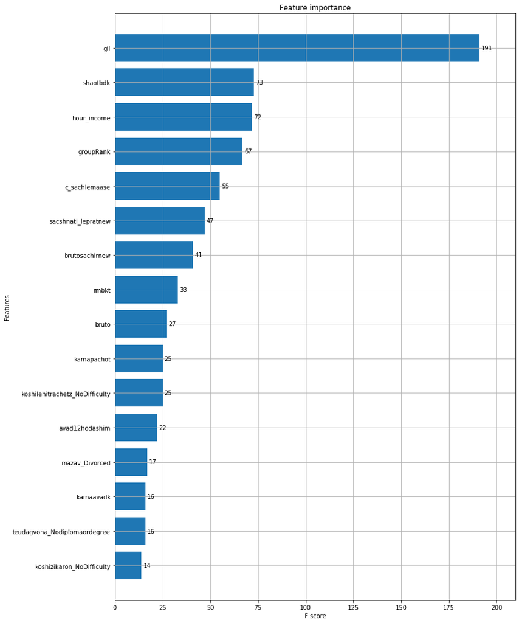

```python
fig, ax = plt.subplots(figsize=(12,18))
xgb.plot_importance(model2, max_num_features=16, height=0.8, ax=ax)
```

### 2.5 Final panel preparation for the model

```python
def load_best_features_data():

    # Checking model results with 16 most important features based on XGboost importance plot:
    data_best=pd.read_csv(root + 'dflearning.csv')

    drops=['id','wave','misparprat','siduri','misparmeshivproxy','mishkalorech',
             'nGroup','n','future_hour_income',
             'incomeGroupUp','incomeGroupDown','s_seker','futereLFP','gilGroup',
             'paamachronachashavani','futureIncomeGroup','gilm','future_mean_income_group','Unnamed: 0']

    best_features=['gil','groupRank','c_sachlemaase','hour_income','shaotbdk', 'bruto',
                  'kamapachot', 'avad12hodashim', 'brutosachirnew', 'yachas','hashavani','mishkalprat',
                  'chipesshana','teudagvoha','rmbkt','min','koshireia']

    # Defining the target variable:
    YLFP=data_best['futereLFP']

    features_to_drop=[]
    for cols in data_best.columns:
        if cols not in best_features:
            features_to_drop.append(cols)

    data_best=data_best.drop(drops+features_to_drop, axis=index_column)
    return data_best, YLFP
```

```python
best_features_data, YLFP =load_best_features_data()
```

```python
best_features_data.shape
```

```
(5117, 17)
```

```python
def best_features_model_results(best_features_data):
    "Function calculates the results of the model with the best features and prints the results."
    "Function returns encoded data, train and test datasets in pandas DataFrame format."

    # Encoding categorical data - One Hot encoding:
    cols=list(best_features_data.select_dtypes(include=['object']).columns)
    X3=pd.get_dummies(data=best_features_data, columns=cols,sparse=True)

    # Spliting data to train and test for the model:
    X_train, X_test, y_train, y_test = model_selection.train_test_split(np.array(X3), YLFP, test_size=test_size,random_state=seed)

    # Mean accuracy on cross validation:
    print("One Hot Encoding - Mean accuracy on the cross validation is:",
    round(np.mean(model_selection.cross_val_score(xgboost, X_train, y_train, cv=skf, scoring='accuracy')),4))

    # Max accuracy on cross validation:
    print("One Hot Encoding - Max accuracy on the cross validation is:",
    round(np.max(model_selection.cross_val_score(xgboost, X_train, y_train, cv=skf, scoring='accuracy')),4))

    # Min accuracy on cross validation:
    print("One Hot Encoding - Min accuracy on the cross validation is:",
    round(np.min(model_selection.cross_val_score(xgboost, X_train, y_train, cv=skf, scoring='accuracy')),4))

    # Fit the model on the train data:
    model2=xgboost.fit(X_train, y_train)

    # Accuracy on test data:
    print("One Hot Encoding - Accuracy on test data is:",
    round(metrics.accuracy_score(y_test, model2.predict(X_test)),4))

    return pd.DataFrame(X3), pd.DataFrame(X_train), pd.DataFrame(X_test), pd.DataFrame(y_train), pd.DataFrame(y_test)
```

```python
X3, X_train, X_test, y_train, y_test = best_features_model_results(best_features_data)
```

```
One Hot Encoding - Mean accuracy on the cross validation is: 0.8676
One Hot Encoding - Max accuracy on the cross validation is: 0.8825
One Hot Encoding - Min accuracy on the cross validation is: 0.8559
One Hot Encoding - Accuracy on test data is: 0.8776
```

**Conclusion**: We noticed the following:

1. The best results were achived using One Hot Encoding technique for categorical features.
2. Model results on the test data with 16 most important features are equal to the model with best results.
3. Maximum and minimum accuracy achived on the cross validation is not significantly different from the mean accuracy.

Therefore based on the results mentioned above, for LFP prediction we decided to use 16 most important features as a final panel. While all categorical fetures were encoded using One Hot Encoding technique.

** For further analysis and models comparison, see chapter 3 below - "Train the models for comparison".

### Data preparation for modeling, various models and encoding technique analysis - Predicting Hourly Income for those who worked

```python
def load_data_hour_income():
    "Function loads and prepares the data for modeling. Function returns data in pandas dataframe format"

    # Load the data from the defined directory:
    dflearning = pd.read_csv(root + 'dflearning.csv')

    # predicted values (y) shouldn't have null values because of the tweedie regression
    data=dflearning[(dflearning['future_hour_income'].notnull())]
    data=data.query('incomeGroup<10')

    # Converting values with minus to the positive values:
    data[data['bruto']<0]=(data[data['bruto']<0])*(-1)
    data[data['brutoazmaishnatinew']<0]=(data[data['brutoazmaishnatinew']<0])*(-1)
    data[data['hour_income']<0]=(data[data['hour_income']<0])*(-1)
    data[data['sacshnati_lepratnew']<0]=(data[data['sacshnati_lepratnew']<0])*(-1)
    data[data['gil']<0]=(data[data['gil']<0])*(-1)
    data[data['shaotbdk']<0]=(data[data['shaotbdk']<0])*(-1)

    # Defining the target variable:
    FuturehourIncome = data['future_hour_income']

    # Preparing the data for the model:
    drops=['id','wave','misparprat','siduri','misparmeshivproxy','mishkalorech',
           'nGroup','n','incomeGroupUp','incomeGroupDown','s_seker','futereLFP','gilGroup','future_hour_income',
           'future_mean_income_group','paamachronachashavani','futureIncomeGroup','gilm','Unnamed: 0']

    data=data.drop(drops,axis=index_column)
    data=data.sample(frac=1)

    # replace all inf with 0 values
    data=data.replace(np.Inf,0.0)

    return data, FuturehourIncome
```

```python
# Calling data_load function:
data, FuturehourIncome=load_data_hour_income()
```

```python
# Features with more than 90% of NaN values:
Null_features_part=[features for features in data.columns
                    if (data[features].isnull().sum()/data.shape[data_len]>null_features_proportion)]

# Drop columns with features were more than 90% of data is Null:
data=data.drop(Null_features_part ,axis=index_column)
```

```python
data.shape
```

[output not shown]

```
(-50, 600)
```

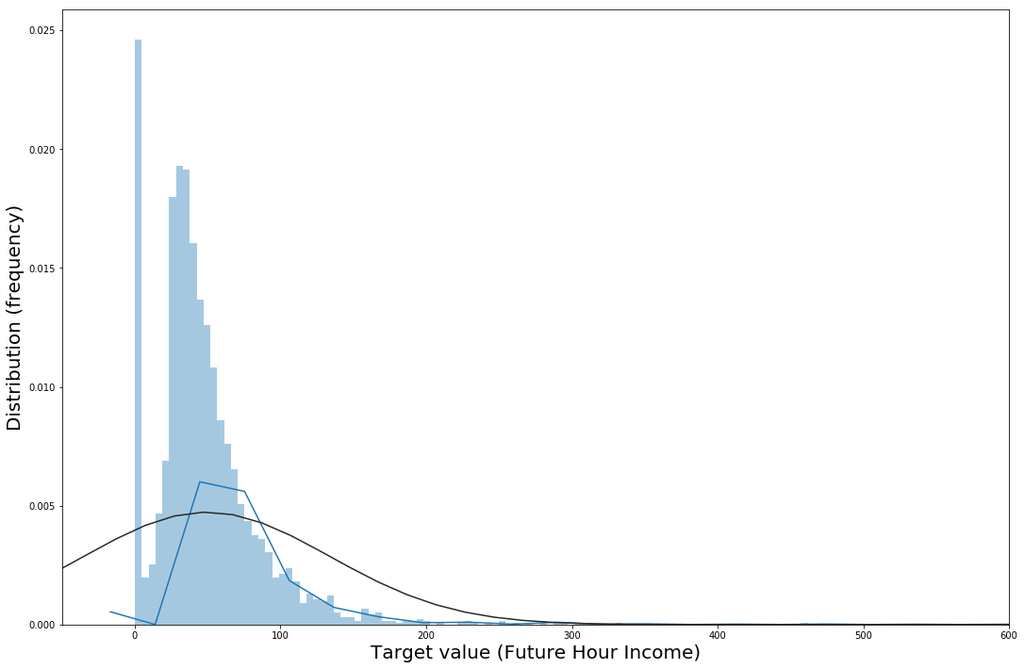

```python
# Ploting the results:
plt.figure(figsize=(18, 12))
sns.distplot(FuturehourIncome, fit=stats.norm, bins=820)
plt.xlabel('Target value (Future Hour Income)', fontsize=20)
plt.ylabel('Distribution (frequency)', fontsize=20)
plt.xlim(-50,600)
```

```python
# Defining the estimator for the model:
xgboost2 = XGBRegressor(max_depth=folds, n_estimators=num_of_trees, objective = 'reg:tweedie',warm_start=True, random_state=seed)
```

```
Text(0,0.5,'Distribution (frequency)')
```

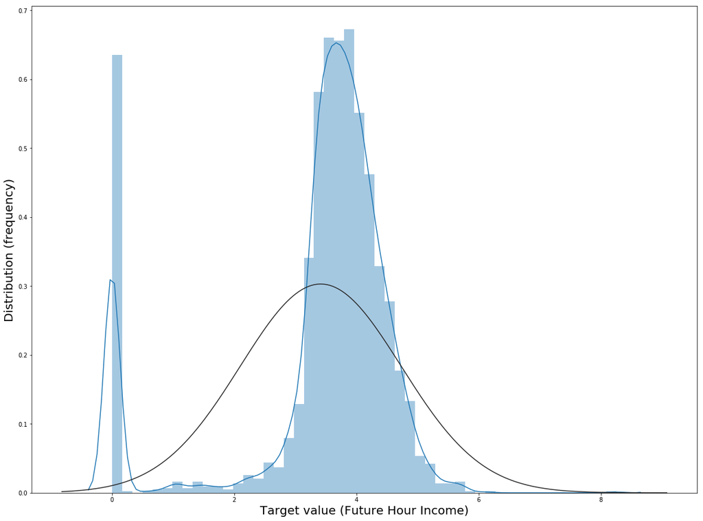

```python
# We use the numpy fuction log1p which  applies log(1+x) to all elements of the FuturehourIncome column:
FuturehourIncome = np.log1p(FuturehourIncome)

# Check the new distribution
plt.figure(figsize=(20, 15))
sns.distplot(FuturehourIncome, fit=stats.norm)
plt.xlabel('Target value (Future Hour Income)', fontsize=20)
plt.ylabel('Distribution (frequency)', fontsize=20)
```

## 3) Models comparison

### 3.1) Models evaluation prior implementing a cross validation

In order to verify and check the effectiveness of XGBoost model, it was decided to compared it with the other models (Random forest, Decision trees and Logistic regression). All algorithms parameters were set to the default settings. The idea was to check which algorithm works better with default parameters "out of the box".

```python
def train_and_predict_models(X_train, y_train, X_test, seed):
    X_train=X_train.fillna(999999) # DecisionTree and Random forest can't obtain NaN values
    y_train=y_train.fillna(999999) # DecisionTree and Random forest can't obtain NaN values
    X_test=X_test.fillna(999999) # DecisionTree and Random forest can't obtain NaN values

    # Train the models:
    #1. Decision Trees
    decision_tree = tree.DecisionTreeClassifier(random_state=seed)
    decision_tree.fit(X_train, y_train)

    #2. Random Forest
    random_forest = ensemble.RandomForestClassifier(random_state=seed)
    random_forest.fit(X_train, y_train)

    #3. Logistic Regression
    logistic_reg = LogisticRegression(random_state=seed)
    logistic_reg.fit(X_train, y_train)

    #4 XGboost
    gbc = ensemble.GradientBoostingClassifier(random_state=seed)
    gbc.fit(X_train, y_train)

    # Predict the labels output and probabilities for each predicted class using the selected models:
    #1 Decision Trees
    decision_tree_predict = decision_tree.predict(X_test)
    decision_tree_predict_prob = decision_tree.predict_proba(X_test)

    #2 Random Forrest
    random_forest_predict = random_forest.predict(X_test)
    random_forest_predict_prob = random_forest.predict_proba(X_test)

    #4 Logistic Regression
    logistic_reg_predict = logistic_reg.predict(X_test)
    logistic_reg_predict_prob = logistic_reg.predict(X_test)

    #3 XGboost
    gbc_y_predict = gbc.predict(X_test)
    gbc_y_pred_prob = gbc.predict_proba(X_test)

    return decision_tree_predict, decision_tree_probability, random_forest_predict, random_forest_predict_probility,
           logistic_reg_predict, logistic_reg_predict_prob, gbc_y_predict, gbc_y_pred_prob
```

```python
# Calling train_and_predict_models function:
decision_tree_predict, decision_tree_probability, random_forest_predict, random_forest_predict_probility,
logistic_reg_predict, logistic_reg_predict_prob, gbc_y_predict, gbc_y_pred_prob = train_and_predict_models(X_train, y_train, X_test, seed)
```

```python
def metrics_evaluation (y_target_values,decision_tree_predict, decision_tree_probability, random_forest_predict,
              random_forest_predict_probility, logistic_reg_predict, logistic_reg_predict_prob, gbc_y_predict, gbc_y_pred_prob):

    "Function prints accuracy and log loss results for each model"

    # Accuracy, log loss for Decision tree:
    decision_tree_accuracy = metrics.accuracy_score(y_test,decision_tree_predict)
    decision_tree_log_loss = metrics.log_loss(y_test,decision_tree_predict_prob)

    # Accuracy, log loss for Random Forest:
    random_forest_accuracy = metrics.accuracy_score(y_test,random_forest_predict)
    random_forest_log_loss = metrics.log_loss(y_test,random_forest_predict_prob)

    # Accuracy, log loss for Logistic regression:
    logistic_reg_accuracy = metrics.accuracy_score(y_test,logistic_reg_predict)
    logistic_reg_predict_prob = metrics.log_loss(y_test,logistic_reg_predict_prob)

    # Accuracy, log loss for XGboost:
    gbc_accuracy = metrics.accuracy_score(y_test, gbc_y_predict)
    gbc_logloss = metrics.log_loss(y_test, gbc_y_pred_prob)

    # Print the results:
    print("The accuracy results for each model are as follows:")
    print('-----------------------------------------------------------------------------------------------------')
    print('-----------------------------------------------------------------------------------------------------')
    print("== Decision Tree ==")
    print("Accuracy: {0:.2f} \n".format(decision_tree_accuracy))
    print("== Random Forest ==")
    print("Accuracy: {0:.2f} \n".format(random_forest_accuracy))
    print("== Logistic Regression ==")
    print("Accuracy: {0:.2f} \n".format(logistic_reg_accuracy))
    print("== Gradient Boosting ==")
    print("Accuracy: {0:.2f} \n".format(gbc_accuracy))
```

```python
def output_results (y_test, decision_tree_predict, decision_tree_predict_prob, random_forest_predict,
                   random_forest_predict_prob, logistic_reg_predict, logistic_reg_predict_prob, gbc_y_predict, gbc_y_pred_prob):
    "Function prints true labels, predicted labels and the number of correct predictions per each model"

    print('-----------------------------------------------------------------------------------------------------')
    print('-----------------------------------------------------------------------------------------------------')
    print("==Decision trees==")
    trees_predict_count=0
    for test, pred in zip(y_test, decision_tree_predict):
        if test==pred:
            trees_predict_count+=1
    result=trees_predict_count/int(y_test.shape[0])
    print('The number of correct predictions is',trees_predict_count,'from the total of', y_test.shape[0],
          'the ratio is: {0:0.3f} \n'.format(result))

    print("===Random forest===")
    forest_predict_count=0
    for test, pred in zip(y_test, random_forest_predict):
        if test==pred:
            forest_predict_count+=1
    result=forest_predict_count/int(y_test.shape[0])
    print('The number of correct predictions is',forest_predict_count,'from the total of', y_test.shape[0],
              'the ratio is: {0:0.3f} \n'.format(result))

    print("===Logistic Regression===")
    logreg_predict_count=0
    for test, pred in zip(y_test, logistic_reg_predict):
        if test==pred:
            logreg_predict_count+=1
    result=logreg_predict_count/int(y_test.shape[0])
    print('The number of correct predictions is',logreg_predict_count,'from the total of', y_test.shape[0],
              'the ratio is: {0:0.3f} \n'.format(result))

    print("== Gradient Boosting ==")
    gb_predict_count=0
    for test, pred in zip(y_test, gbc_y_predict):
        if test==pred:
            gb_predict_count+=1
    result=gb_predict_count/int(y_test.shape[0])
    print('The number of correct predictions is',gb_predict_count,'from the total of', y_test.shape[0],
          'the ratio is: {0:0.3f}'.format(result))
    print('-----------------------------------------------------------------------------------------------------')
    print('-----------------------------------------------------------------------------------------------------')
```

```python
# Calling "metrics_evaluation" and "output_results" functions:

metrics_evaluation(y_test, decision_tree_predict, decision_tree_predict_prob, random_forest_predict, random_forest_predict_prob,
                    logistic_reg_predict, logistic_reg_predict_prob, gbc_y_predict, gbc_y_pred_prob)

output_results(y_test, decision_tree_predict, decision_tree_predict_prob, random_forest_predict
               ,random_forest_predict_prob, logistic_reg_predict, logistic_reg_predict_prob, gbc_y_predict, gbc_y_pred_prob)
```

```
The accuracy results for each model are as follows:
-----------------------------------------------------------------------------------------------------
-----------------------------------------------------------------------------------------------------
== Decision Tree ==
Accuracy: 0.80

== Random Forest ==
Accuracy: 0.86

== Logistic Regression ==
Accuracy: 0.84

== Gradient Boosting ==
Accuracy: 0.88

-----------------------------------------------------------------------------------------------------
-----------------------------------------------------------------------------------------------------
==Decision trees==
The number of correct predictions is 1235 from the total of 1536 the ratio is: 0.804

===Random forest===
The number of correct predictions is 1326 from the total of 1536 the ratio is: 0.863

===Logistic Regression===
The number of correct predictions is 1287 from the total of 1536 the ratio is: 0.838

== Gradient Boosting ==
The number of correct predictions is 1348 from the total of 1536 the ratio is: 0.878
-----------------------------------------------------------------------------------------------------
-----------------------------------------------------------------------------------------------------
```

**Conclusion:** From the results above we can see that in comparison with a Decision trees, Random forest and Logistic regression model, XGboost model outputs better accuracy results "out of the box", without tuning parameters.

### 3.2) Models evaluation using a cross validation

Taking in the consideration the fact that we are dealing with the classification problem (LFP prediction), the following metrics were selected in order to compare the models side by side using a cross validation:

- Accuracy - Measures the classification model accuracy as the proportion of true results to total cases.
- Precision - The proportion of true results over all positive results.
- Recall - The fraction of all correct results returned by the model.
- F-score - Computed as the weighted average of precision and recall between 0 and 1, where the ideal F-score value is 1.
- AUC - Measures the area under the curve plotted with true positives on the y axis and false positives on the x axis.
- Log loss - A single score used to express the penalty for wrong results. It is calculated as the difference between two probability distributions – the true one, and the one in the model.

```python
# Define a list of models and metrics to evaluate:
methods=['accuracy','recall','precision','f1','log_loss','roc_auc']
models=['decision_tree','random_forest','logistic_regression','gbc']

# Cross validation strategy defenition:
cv_strategy = model_selection.StratifiedShuffleSplit(n_splits = folds ,test_size = test_size, random_state = seed)
```

```python
def cross_val_score (X, y, seed, methods, models, cv_strategy):
    "Function evaluates model performance using a Stratified Cross Validation for the selected metrics:"

    decision_trees=[]
    scores=[]
    random_forests=[]
    logistic_regression=[]
    gxboost=[]
    for model in models:
        if model=='decision_tree':
            for method in methods:
                scoring = cross_validation.cross_val_score(decision_tree, X, y, scoring = method, cv = cv_strategy)
                k=np.mean(scoring)
                decision_trees.append(k)
        elif model=='random_forest':
            for method in methods:
                scoring = cross_validation.cross_val_score(random_forest, X, y, scoring = method, cv = cv_strategy)
                k=np.mean(scoring)
                random_forests.append(k)
        elif model=='logistic_regression':
            for method in methods:
                scoring = cross_validation.cross_val_score(logistic_reg, X, y, scoring = method, cv = cv_strategy)
                k=np.mean(scoring)
                logistic_regression.append(k)
        else:
            for method in methods:
                scoring = cross_validation.cross_val_score(gbc, X, y, scoring = method, cv = cv_strategy)
                k=np.mean(scoring)
                gxboost.append(k)
    return decision_trees, random_forests, logistic_regression, gxboost
```

```python
# Print the cross validation results:
print('Results using cross validation results per each model for the selected metrics:')
print("------------------------------------------------------------------------------")
cross_val_data=pd.DataFrame(np.array(cross_val_data), columns=['Accuracy','Recall','Precision','F-Score','Log loss','Roc Auc'],
                           index=['Decision trees','Random forest','Logistic Regression', 'XGboost'])
cross_val_data['Log loss']=cross_val_data['Log loss']*(-1)
cross_val_data.sort_values(by='Accuracy', ascending=False)
```

```
Results using cross validation results per each model for the selected metrics:
------------------------------------------------------------------------------
```

|  | Accuracy | Recall | Precision | F-Score | Log loss | Roc Auc |
| --- | --- | --- | --- | --- | --- | --- |
| XGboost | 0.871354 | 0.931653 | 0.876978 | 0.903430 | 0.330299 | 0.911866 |
| Random forest | 0.859245 | 0.913911 | 0.874110 | 0.893493 | 1.133726 | 0.890174 |
| Logistic Regression | 0.842578 | 0.876613 | 0.879311 | 0.877934 | 0.424036 | 0.857782 |
| Decision trees | 0.805339 | 0.835685 | 0.859110 | 0.847220 | 6.723369 | 0.792843 |

**Conclusion:** As can be seen from the table above XGBOOST model achived the best results in almost all metrics.

## 4) Learning curves

### Curves to build:

- Train data errors vs Cross validation errors - To analyze the error (log loss) as a function of train data sizes.
- Accuracy vs Number of trees and max depth - To analyze two main parameters which should be tuned afterwards.

```python
# Define varibales for the learning curves and parameters tuning:
cv_strategy = cross_validation.StratifiedShuffleSplit(y, n_iter = 5 ,test_size = test_size, random_state = seed)
number_of_trees = [1] + list(range(5, 150, 10))
depth=[1] + list(range(5, 60, 5))
trees=5
trees_depth=5
features =list(range(1, 46, 2))
score_method='accuracy'
train_sizes=np.arange(0.1, 1, 0.05)
```

### 4.1) Train data errors vs Cross validation errors - Bias vs Variance trade off

**Bias** - Bias is the difference between our model prediction and the correct value which we are trying to predict. Model with high bias pays very little attention to the training data and oversimplifies the model. It always leads to high error on training and test data.

**Variance** - Variance is the variability of model prediction for a given data point or a value which tells us spread of our data. Model with high variance pays a lot of attention to training data and sometimes does not generalize on the data which it hasn’t seen before. As a result, such models perform very well on training data but has a potential of higher error rates on test data.

[figure not shown]

In order to identify if we are dealing with high variance or high bias problem we built a graph of model error as a function of training set size for train data and test data (CV).

```python
def Errors_vs_data_sizes (trees, score_method, seed, train_sizes, X=data, y=YLFP):
    "Function plots log loss error rates on the cross validation and the train data:"

    estimator = XGBClassifier(max_depth=trees_depth,n_estimators=trees,warm_start=True,random_state=seed)
    train_sizes, train_scores, test_scores = model_selection.learning_curve(estimator, X, y,
                                                                     train_sizes=train_sizes,
                                                                     cv=cv_strategy, scoring='log_loss')
    plt.figure(figsize=(10, 6), dpi=90)
    plt.plot(train_sizes, abs(train_scores.mean(axis = 1)), marker='.', label='Train data error', color='r')
    plt.plot(train_sizes, abs(test_scores.mean(axis = 1)), marker='.', label='Cross validation error', color='g')
    plt.grid(True)
    plt.xlabel('Train data sizes')
    plt.ylabel('Error')
    plt.xlim(0, 3500)
    plt.title('Train error vs Cross validation error')
    plt.legend(loc='lower right')
```

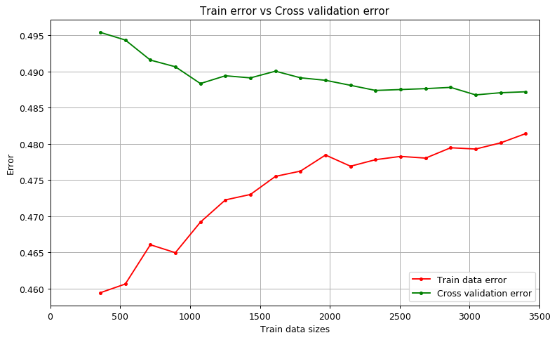

```python
Errors_vs_data_sizes (trees, score_method, seed, train_sizes)
```

- Find optimal depth of each tree (max_depth)
- Add more randomness using subsample, colsample_bytree parameters
- Check the optimal of lambda and gamma regularization parameters - Increasing regularization (add penalties for extra complexity)

### 4.2) Accuracy vs Number of trees and max depth

In addition we checked the potential range of 2 main parameters to be tuned and their influence on the accuracy score: number of trees and max depth of each tree.

```python
def Accuracy_on_CV (number_of_trees, depth, score_method, cv_strategy, trees, seed, X=data, y=YLFP):
    "The function plots the number of trees and max_depth vs accuracy score"

    # Estimation of accuracy vs number of trees:
    xgb_scoring_tree = []
    for n_tree in number_of_trees:
        estimator = XGBClassifier(max_depth=trees_depth,n_estimators=n_tree, random_state=seed)
        score = model_selection.cross_val_score(estimator, X, y, cv=cv_strategy, scoring = score_method)
        xgb_scoring_tree.append(score)
    xgb_scoring_tree = np.asmatrix(xgb_scoring_tree)

    # Estimation of accuracy vs tree depth:
    xgb_scoring_depth = []
    for depth_score in depth:
        estimator = XGBClassifier(max_depth=trees_depth,n_estimators=trees,random_state=seed)
        score = model_selection.cross_val_score(estimator, X, y, cv=cv_strategy, scoring = score_method)
        xgb_scoring_depth.append(score)
    xgb_scoring_depth = np.asmatrix(xgb_scoring_depth)
    plt.figure(figsize=(10, 6), dpi=90)
    plt.plot(number_of_trees, xgb_scoring_tree.mean(axis = 1), marker='.', label='Number of trees')
    plt.plot(depth, xgb_scoring_depth.mean(axis = 1), marker='.', label='Max_depth')
    plt.grid(True)
    plt.ylabel('Accuracy Score')
    plt.legend(loc='lower right')
```

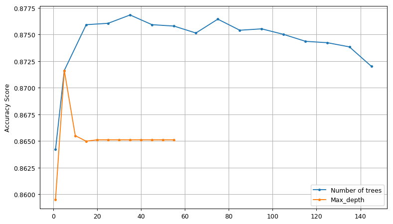

```python
Accuracy_on_CV (number_of_trees, depth, score_method, cv_strategy, trees, seed)
```

#### Conclusion:

From the results above we can see that the best accuracy was obtained when the max_depth is less than 10 (around 3-5). In addition we can see that adding more than 40 tress is not leading to significant accuracy gain. Moreover, after about 100 trees the accuracy starting to decrease. These facts should be taken in the consuderation while tuning the model parameters.

## 5. Explore the model in order to improve the results

### 5.1 Grid-search implementation

For the Grid-search the following parameters to be tuned were selected: max_features, min_samples_leaf, max_depth, n_estimators and learning_rate.

```python
# Initialize the set of parameters for exhaustive search and fit:

parameters = {'max_features': [3, 4, 5, 6], 'min_samples_leaf': [2, 3, 4, 5], 'max_depth': [3, 4, 5, 6, 7],
             'n_estimators': [50, 75],'learning_rate': [0.01, 0.025, 0.05, 0.1]}
gcv = model_selection.GridSearchCV(model2, parameters, n_jobs=-1, cv=cv_strategy, verbose=1)
gcv.fit(X, y)
```

[output not shown]

```
[Parallel(n_jobs=-1)]: Using backend LokyBackend with 4 concurrent workers.
[Parallel(n_jobs=-1)]: Done  76 tasks      | elapsed:    2.3s
[Parallel(n_jobs=-1)]: Done 376 tasks      | elapsed:   14.7s
[Parallel(n_jobs=-1)]: Done 876 tasks      | elapsed:   36.0s
[Parallel(n_jobs=-1)]: Done 1576 tasks      | elapsed:  1.1min
[Parallel(n_jobs=-1)]: Done 2048 out of 2048 | elapsed:  1.5min finished
```

[output not shown]

```python
# Checking the best model parameters:
gcv.best_estimator_, gcv.best_score_
```

```
(GradientBoostingClassifier(criterion='friedman_mse', init=None,
               learning_rate=0.1, loss='deviance', max_depth=5,
               max_features=6, max_leaf_nodes=None,
               min_impurity_decrease=0.0, min_impurity_split=None,
               min_samples_leaf=2, min_samples_split=2,
               min_weight_fraction_leaf=0.0, n_estimators=75,
               n_iter_no_change=None, presort='auto', random_state=30,
               subsample=1.0, tol=0.0001, validation_fraction=0.1,
               verbose=0, warm_start='False'), 0.8725815907758452)
```

**The accuracy best score achived using a grid-search is 0.8726**

### 5.2 Manual parameters tuning

```python
# 1.1 Set a number of trees and learning rate fixed and find optimal number of max_depth:

params_grid = {
    'max_depth': [3,4,5,6,7,8,9]
}

# Add a dictionary for fixed parameters.
params_fixed  = {
    'objective': 'binary:logistic',
    'silent': 1,
    'learning_rate': 0.1,
    'n_estimators': 40,
    'warm_start': True
}

# Create a GridSearchCV estimator. We will be looking for combination giving the best accuracy.
bst_grid = GridSearchCV(
    estimator=XGBClassifier(**params_fixed, seed=seed),
    param_grid=params_grid,
    cv=cv_strategy,
    scoring='accuracy',
    n_jobs=-1,
    verbose=1
)
bst_grid.fit(X, y)


bst_grid.grid_scores_

print("Best Accuracy obtained: {0}".format(bst_grid.best_score_))
print("Parameters:")
for key, value in bst_grid.best_params_.items():
    print("\t{}: {}".format(key, value))

scores = pd.DataFrame(bst_grid.grid_scores_).sort_values(by='mean_validation_score', ascending=False)
scores
```

```
Fitting 5 folds for each of 7 candidates, totalling 35 fits
```

```
[Parallel(n_jobs=-1)]: Done  35 out of  35 | elapsed:    7.7s finished
```

```
Best Accuracy obtained: 0.8670572916666667
Parameters:
	max_depth: 4
```

|  | parameters | mean_validation_score | cv_validation_scores |
| --- | --- | --- | --- |
| 1 | {'max_depth': 4} | 0.867057 | [0.869140625, 0.8782552083333334, 0.873046875,... |
| 2 | {'max_depth': 5} | 0.866536 | [0.869140625, 0.876953125, 0.8723958333333334,... |
| 4 | {'max_depth': 7} | 0.865625 | [0.86328125, 0.8684895833333334, 0.86588541666... |
| 3 | {'max_depth': 6} | 0.864974 | [0.8704427083333334, 0.873046875, 0.8678385416... |
| 0 | {'max_depth': 3} | 0.864062 | [0.8697916666666666, 0.8723958333333334, 0.868... |
| 5 | {'max_depth': 8} | 0.861719 | [0.8567708333333334, 0.87109375, 0.86197916666... |
| 6 | {'max_depth': 9} | 0.859766 | [0.8561197916666666, 0.8678385416666666, 0.860... |

```python
# 1.2 Set a number of trees and learning rate fixed and find optimal number of min_child_weight:

params_grid = {
    'min_child_weight': [2, 3, 4, 5, 6, 7]
}

# Add a dictionary for fixed parameters.
params_fixed  = {
    'objective': 'binary:logistic',
    'silent': 1,
    'learning_rate': 0.1,
    'max_depth': 4,
    'n_estimators': 40,
    'warm_start': True
}

# Create a GridSearchCV estimator. We will be looking for combination giving the best accuracy.
bst_grid = GridSearchCV(
    estimator=XGBClassifier(**params_fixed, seed=seed),
    param_grid=params_grid,
    cv=cv_strategy,
    scoring='accuracy',
    n_jobs=-1,
    verbose=1
)
bst_grid.fit(X, y)

bst_grid.grid_scores_

print("Best accuracy obtained: {0}".format(bst_grid.best_score_))
for key, value in bst_grid.best_params_.items():
    print("\t{}: {}".format(key, value))

scores = pd.DataFrame(bst_grid.grid_scores_).sort_values(by='mean_validation_score', ascending=False)
scores
```

```
Fitting 5 folds for each of 6 candidates, totalling 30 fits
```

```
[Parallel(n_jobs=-1)]: Done  30 out of  30 | elapsed:    5.9s finished
```

```
Best accuracy obtained: 0.868359375
	min_child_weight: 3
```

|  | parameters | mean_validation_score | cv_validation_scores |
| --- | --- | --- | --- |
| 1 | {'min_child_weight': 3} | 0.868359 | [0.8684895833333334, 0.8782552083333334, 0.874... |
| 0 | {'min_child_weight': 2} | 0.867708 | [0.8697916666666666, 0.8776041666666666, 0.871... |
| 2 | {'min_child_weight': 4} | 0.867578 | [0.8717447916666666, 0.8763020833333334, 0.873... |
| 4 | {'min_child_weight': 6} | 0.866667 | [0.8704427083333334, 0.87890625, 0.86979166666... |
| 5 | {'min_child_weight': 7} | 0.866406 | [0.8678385416666666, 0.8756510416666666, 0.875... |
| 3 | {'min_child_weight': 5} | 0.866146 | [0.8665364583333334, 0.875, 0.873046875, 0.854... |

```python
# 1.3 Set a number of trees and learning rate fixed and find optimal number of subsample, colsample_bytree, colsample_bylevel:
params_grid = {
    'subsample':[i/10.0 for i in range(3,10)],
    'colsample_bytree':[i/10.0 for i in range(3,10)],
    'colsample_bylevel':[i/10.0 for i in range(3,10)]
}

# Add a dictionary for fixed parameters.
params_fixed  = {
    'objective': 'binary:logistic',
    'silent': 1,
    'learning_rate': 0.1,
    'max_depth': 4,
    'n_estimators': 40,
    'min_child_weight': 3
}

# Create a GridSearchCV estimator. We will be looking for combination giving the best accuracy.
bst_grid = GridSearchCV(
    estimator=XGBClassifier(**params_fixed, seed=seed),
    param_grid=params_grid,
    cv=cv_strategy,
    scoring='accuracy',
    n_jobs=-1,
    verbose=1
)
bst_grid.fit(X, y)

bst_grid.grid_scores_

print("Best accuracy obtained: {0}".format(bst_grid.best_score_))

for key, value in bst_grid.best_params_.items():
    print("\t{}: {}".format(key, value))

scores = pd.DataFrame(bst_grid.grid_scores_).sort_values(by='mean_validation_score', ascending=False)
scores
```

```
Fitting 5 folds for each of 343 candidates, totalling 1715 fits
```

```
[Parallel(n_jobs=-1)]: Done  42 tasks      | elapsed:    5.2s
[Parallel(n_jobs=-1)]: Done 192 tasks      | elapsed:   10.6s
[Parallel(n_jobs=-1)]: Done 442 tasks      | elapsed:   21.6s
[Parallel(n_jobs=-1)]: Done 792 tasks      | elapsed:   37.9s
[Parallel(n_jobs=-1)]: Done 1242 tasks      | elapsed:  1.0min
[Parallel(n_jobs=-1)]: Done 1715 out of 1715 | elapsed:  1.5min finished
```

```
Best accuracy obtained: 0.8704427083333334
	colsample_bylevel: 0.7
	colsample_bytree: 0.8
	subsample: 0.3
```

|  | parameters | mean_validation_score | cv_validation_scores |
| --- | --- | --- | --- |
| 231 | {'colsample_bylevel': 0.7, 'colsample_bytree':... | 0.870443 | [0.8665364583333334, 0.8815104166666666, 0.871... |
| 278 | {'colsample_bylevel': 0.8, 'colsample_bytree':... | 0.870052 | [0.8743489583333334, 0.8815104166666666, 0.876... |
| 220 | {'colsample_bylevel': 0.7, 'colsample_bytree':... | 0.870052 | [0.8782552083333334, 0.8802083333333334, 0.867... |
| 182 | {'colsample_bylevel': 0.6, 'colsample_bytree':... | 0.870052 | [0.8723958333333334, 0.880859375, 0.8697916666... |
| 192 | {'colsample_bylevel': 0.6, 'colsample_bytree':... | 0.869922 | [0.8697916666666666, 0.884765625, 0.87109375, ... |
| 262 | {'colsample_bylevel': 0.8, 'colsample_bytree':... | 0.869922 | [0.8782552083333334, 0.8776041666666666, 0.871... |
| 323 | {'colsample_bylevel': 0.9, 'colsample_bytree':... | 0.869922 | [0.8763020833333334, 0.8782552083333334, 0.873... |
| 260 | {'colsample_bylevel': 0.8, 'colsample_bytree':... | 0.869792 | [0.8776041666666666, 0.8782552083333334, 0.876... |
| 143 | {'colsample_bylevel': 0.5, 'colsample_bytree':... | 0.869792 | [0.8704427083333334, 0.8802083333333334, 0.875... |
| 90 | {'colsample_bylevel': 0.4, 'colsample_bytree':... | 0.869661 | [0.8763020833333334, 0.8782552083333334, 0.871... |
| 313 | {'colsample_bylevel': 0.9, 'colsample_bytree':... | 0.869661 | [0.875, 0.8795572916666666, 0.8704427083333334... |
| 242 | {'colsample_bylevel': 0.7, 'colsample_bytree':... | 0.869531 | [0.8704427083333334, 0.8821614583333334, 0.870... |
| 235 | {'colsample_bylevel': 0.7, 'colsample_bytree':... | 0.869531 | [0.87109375, 0.8841145833333334, 0.873046875, ... |
| 191 | {'colsample_bylevel': 0.6, 'colsample_bytree':... | 0.869531 | [0.8684895833333334, 0.8821614583333334, 0.872... |
| 326 | {'colsample_bylevel': 0.9, 'colsample_bytree':... | 0.869401 | [0.8736979166666666, 0.8795572916666666, 0.870... |
| 193 | {'colsample_bylevel': 0.6, 'colsample_bytree':... | 0.869401 | [0.8671875, 0.8828125, 0.8723958333333334, 0.8... |
| 240 | {'colsample_bylevel': 0.7, 'colsample_bytree':... | 0.869271 | [0.8736979166666666, 0.8802083333333334, 0.871... |
| 269 | {'colsample_bylevel': 0.8, 'colsample_bytree':... | 0.869271 | [0.8776041666666666, 0.876953125, 0.865234375,... |
| 95 | {'colsample_bylevel': 0.4, 'colsample_bytree':... | 0.869271 | [0.8756510416666666, 0.8795572916666666, 0.872... |
| 311 | {'colsample_bylevel': 0.9, 'colsample_bytree':... | 0.869271 | [0.875, 0.880859375, 0.8704427083333334, 0.852... |
| 241 | {'colsample_bylevel': 0.7, 'colsample_bytree':... | 0.869141 | [0.8697916666666666, 0.8782552083333334, 0.875... |
| 221 | {'colsample_bylevel': 0.7, 'colsample_bytree':... | 0.869141 | [0.8756510416666666, 0.8776041666666666, 0.869... |
| 277 | {'colsample_bylevel': 0.8, 'colsample_bytree':... | 0.869141 | [0.8763020833333334, 0.8776041666666666, 0.871... |
| 239 | {'colsample_bylevel': 0.7, 'colsample_bytree':... | 0.869141 | [0.873046875, 0.8795572916666666, 0.8776041666... |
| 234 | {'colsample_bylevel': 0.7, 'colsample_bytree':... | 0.869141 | [0.8723958333333334, 0.8795572916666666, 0.875... |
| 310 | {'colsample_bylevel': 0.9, 'colsample_bytree':... | 0.869141 | [0.8736979166666666, 0.8815104166666666, 0.868... |
| 94 | {'colsample_bylevel': 0.4, 'colsample_bytree':... | 0.869141 | [0.869140625, 0.8815104166666666, 0.8717447916... |
| 263 | {'colsample_bylevel': 0.8, 'colsample_bytree':... | 0.869010 | [0.8736979166666666, 0.8776041666666666, 0.871... |
| 89 | {'colsample_bylevel': 0.4, 'colsample_bytree':... | 0.869010 | [0.8763020833333334, 0.876953125, 0.873046875,... |
| 215 | {'colsample_bylevel': 0.7, 'colsample_bytree':... | 0.869010 | [0.8782552083333334, 0.8776041666666666, 0.869... |

[output cut: 313 more lines]

```python
# 1.4 Set a number of trees and learning rate fixed and find optimal number of gamma, reg_alpha:
params_grid = {
    'reg_alpha':[0, 0.01, 0.05, 0.1, 0.02, 0.025, 0.03, 0.04, 0.05, 0.06, 0.07, 0.08, 1],
    'gamma':[0, 0.01, 0.05, 0.1, 0.02, 0.025, 0.03, 0.04, 0.05, 0.06, 0.07, 0.08, 1]
}

# Add a dictionary for fixed parameters.
params_fixed  = {
    'objective': 'binary:logistic',
    'silent': 1,
    'max_depth': 4,
    'learning_rate': 0.1,
    'n_estimators': 40,
    'min_child_weight': 3,
    'colsample_bytree': 0.8,
    'colsample_bylevel':0.7,
    'subsample': 0.3
}

# Create a GridSearchCV estimator. We will be looking for combination giving the best accuracy.
bst_grid = GridSearchCV(
    estimator=XGBClassifier(**params_fixed, seed=seed),
    param_grid=params_grid,
    cv=cv_strategy,
    scoring='accuracy',
    n_jobs=-1,
    verbose=1
)
bst_grid.fit(X, y)

bst_grid.grid_scores_

print("Best accuracy obtained: {0}".format(bst_grid.best_score_))
print("Parameters:")
for key, value in bst_grid.best_params_.items():
    print("\t{}: {}".format(key, value))

scores = pd.DataFrame(bst_grid.grid_scores_)
scores.iloc[:,0:2].sort_values(by='mean_validation_score', ascending=False)
```

```
Fitting 5 folds for each of 169 candidates, totalling 845 fits
```

```
[Parallel(n_jobs=-1)]: Done  42 tasks      | elapsed:    6.8s
[Parallel(n_jobs=-1)]: Done 192 tasks      | elapsed:   16.0s
[Parallel(n_jobs=-1)]: Done 442 tasks      | elapsed:   31.5s
[Parallel(n_jobs=-1)]: Done 792 tasks      | elapsed:   53.4s
[Parallel(n_jobs=-1)]: Done 845 out of 845 | elapsed:   56.7s finished
```

```
Best accuracy obtained: 0.870703125
Parameters:
	gamma: 0.025
	reg_alpha: 0
```

|  | parameters | mean_validation_score |
| --- | --- | --- |
| 65 | {'gamma': 0.025, 'reg_alpha': 0} | 0.870703 |
| 0 | {'gamma': 0, 'reg_alpha': 0} | 0.870443 |
| 78 | {'gamma': 0.03, 'reg_alpha': 0} | 0.870443 |
| 52 | {'gamma': 0.02, 'reg_alpha': 0} | 0.870443 |
| 13 | {'gamma': 0.01, 'reg_alpha': 0} | 0.870443 |
| 39 | {'gamma': 0.1, 'reg_alpha': 0} | 0.870313 |
| 26 | {'gamma': 0.05, 'reg_alpha': 0} | 0.869792 |
| 104 | {'gamma': 0.05, 'reg_alpha': 0} | 0.869792 |
| 91 | {'gamma': 0.04, 'reg_alpha': 0} | 0.869792 |
| 143 | {'gamma': 0.08, 'reg_alpha': 0} | 0.869661 |
| 117 | {'gamma': 0.06, 'reg_alpha': 0} | 0.869661 |
| 1 | {'gamma': 0, 'reg_alpha': 0.01} | 0.869661 |
| 4 | {'gamma': 0, 'reg_alpha': 0.02} | 0.869531 |
| 130 | {'gamma': 0.07, 'reg_alpha': 0} | 0.869531 |
| 14 | {'gamma': 0.01, 'reg_alpha': 0.01} | 0.869401 |
| 144 | {'gamma': 0.08, 'reg_alpha': 0.01} | 0.869271 |
| 84 | {'gamma': 0.03, 'reg_alpha': 0.03} | 0.869271 |
| 31 | {'gamma': 0.05, 'reg_alpha': 0.025} | 0.869141 |
| 134 | {'gamma': 0.07, 'reg_alpha': 0.02} | 0.869141 |
| 135 | {'gamma': 0.07, 'reg_alpha': 0.025} | 0.869141 |
| 40 | {'gamma': 0.1, 'reg_alpha': 0.01} | 0.869141 |
| 53 | {'gamma': 0.02, 'reg_alpha': 0.01} | 0.869141 |
| 122 | {'gamma': 0.06, 'reg_alpha': 0.025} | 0.869141 |
| 109 | {'gamma': 0.05, 'reg_alpha': 0.025} | 0.869141 |
| 147 | {'gamma': 0.08, 'reg_alpha': 0.02} | 0.869141 |
| 148 | {'gamma': 0.08, 'reg_alpha': 0.025} | 0.869141 |
| 121 | {'gamma': 0.06, 'reg_alpha': 0.02} | 0.869141 |
| 43 | {'gamma': 0.1, 'reg_alpha': 0.02} | 0.869010 |
| 82 | {'gamma': 0.03, 'reg_alpha': 0.02} | 0.869010 |
| 32 | {'gamma': 0.05, 'reg_alpha': 0.03} | 0.869010 |

[output cut: 139 more lines]

```python
# 1.5 Find optimal learning rate:
params_grid = {
   'learning_rate':[0.001, 0.005, 0.055, 0.01, 0.02, 0.025, 0.03, 0.04, 0.05, 0.06, 0.07, 0.08, 0.1, 0.5, 1]

}

# Add a dictionary for fixed parameters.
params_fixed  = {
    'objective': 'binary:logistic',
    'silent': 1,
    'max_depth': 4,
    'n_estimators': 40,
    'min_child_weight': 3,
    'colsample_bytree': 0.8,
    'colsample_bylevel':0.7,
    'gamma':0.025,
    'subsample': 0.3
}

# Create a GridSearchCV estimator. We will be looking for combination giving the best accuracy.
bst_grid = GridSearchCV(
    estimator=XGBClassifier(**params_fixed, seed=seed),
    param_grid=params_grid,
    cv=cv_strategy,
    scoring='accuracy',
    n_jobs=-1,
    verbose=1
)
bst_grid.fit(X, y)

bst_grid.grid_scores_

print("Best accuracy obtained: {0}".format(bst_grid.best_score_))
print("Parameters:")
for key, value in bst_grid.best_params_.items():
    print("\t{}: {}".format(key, value))

scores = pd.DataFrame(bst_grid.grid_scores_)
scores.iloc[:,0:2].sort_values(by='mean_validation_score', ascending=False)
```

```
Fitting 5 folds for each of 15 candidates, totalling 75 fits
```

```
[Parallel(n_jobs=-1)]: Done  42 tasks      | elapsed:    6.2s
[Parallel(n_jobs=-1)]: Done  75 out of  75 | elapsed:    8.2s finished
```

```
Best accuracy obtained: 0.870703125
Parameters:
	learning_rate: 0.1
```

|  | parameters | mean_validation_score |
| --- | --- | --- |
| 12 | {'learning_rate': 0.1} | 0.870703 |
| 10 | {'learning_rate': 0.07} | 0.869922 |
| 11 | {'learning_rate': 0.08} | 0.868099 |
| 9 | {'learning_rate': 0.06} | 0.867969 |
| 2 | {'learning_rate': 0.055} | 0.867839 |
| 6 | {'learning_rate': 0.03} | 0.867839 |
| 7 | {'learning_rate': 0.04} | 0.867188 |
| 8 | {'learning_rate': 0.05} | 0.867188 |
| 4 | {'learning_rate': 0.02} | 0.867057 |
| 1 | {'learning_rate': 0.005} | 0.866016 |
| 5 | {'learning_rate': 0.025} | 0.865885 |
| 3 | {'learning_rate': 0.01} | 0.865234 |
| 0 | {'learning_rate': 0.001} | 0.864323 |
| 13 | {'learning_rate': 0.5} | 0.850911 |
| 14 | {'learning_rate': 1} | 0.812891 |

```python
# Best estimator parameters:
bst_grid.best_estimator_
```

```
XGBClassifier(base_score=0.5, booster='gbtree', colsample_bylevel=0.7,
       colsample_bytree=0.8, gamma=0.025, learning_rate=0.1,
       max_delta_step=0, max_depth=4, min_child_weight=3, missing=None,
       n_estimators=40, n_jobs=1, nthread=None,
       objective='binary:logistic', random_state=0, reg_alpha=0,
       reg_lambda=1, scale_pos_weight=1, seed=30, silent=1, subsample=0.3)
```

### 5.3 Early stop strategy

Early stopping is a method that allows you to specify an arbitrary large number of training and stop training once the model performance stops improving on a hold out validation dataset in order to overfitting of the training dataset.

```python
dtrain = xgb.DMatrix(X_train, y_train)
dtest = xgb.DMatrix(X_test, y_test)

params = {
    'objective': 'binary:logistic',
    'silent': 1,
    'max_depth': 4,
    'learning_rate': 0.1,
    'min_child_weight': 3,
    'colsample_bytree': 0.8,
    'colsample_bylevel':0.7,
    'gamma': 0.025,
    'subsample': 0.3,
    'seed': 30,
    'eval_metric':['error']

}
watchlist = [(dtest,'test'), (dtrain,'train')]
```

```python
num_rounds = 1500

evals_result = {}
xgb_model = xgb.train(params, dtrain, num_rounds, watchlist, early_stopping_rounds=10,
                      evals_result=evals_result)
```

[output not shown]

```python
print("Booster best iteration: {}".format(xgb_model.best_iteration))
```

```
Booster best iteration: 57
```

```python
cvresult = xgb.cv(params, dtrain, nfold=5, metrics=['auc','logloss','error'], num_boost_round=num_rounds,
                  early_stopping_rounds=10,  callbacks=[xgb.callback.print_evaluation(show_stdv=False)])
cvresult1=pd.DataFrame(cvresult)
cvresult1.mean()
```

```
train-auc-mean        0.931347
train-auc-std         0.002720
train-error-mean      0.117126
train-error-std       0.001402
train-logloss-mean    0.342101
train-logloss-std     0.003417
test-auc-mean         0.912449
test-auc-std          0.012787
test-error-mean       0.129312
test-error-std        0.005497
test-logloss-mean     0.366728
test-logloss-std      0.011315
dtype: float64
```

```python
params = {
    'objective': 'binary:logistic',
    'silent': 1,
    'max_depth': 4,
    'learning_rate': 0.1,
    'min_child_weight': 3,
    'colsample_bytree': 0.8,
    'colsample_bylevel':0.7,
    'gamma': 0.025,
    'subsample': 0.3,
    'n_estimators': 57,
    'seed': 30}

eval_set  = [(X_train,y_train), (X_test,y_test)]
tuned_model=XGBClassifier(**params)
tuned_model.fit(X_train, y_train, sample_weight=X_train_weight,sample_weight_eval_set=[X_train_weight,X_test_weight])
# Accuracy on test data:
print("Tuned parameters - Accuracy on test data is:",
round(metrics.accuracy_score(y_test, tuned_model.predict(X_test)),4))
```

```
Tuned parameters - Accuracy on test data is: 0.9333
```

**Conclusion**: From the results above we found that the manual tuning results (0.9333) is higher than the automated gridsearch performed (0.8726).

```
(0, 60)
```

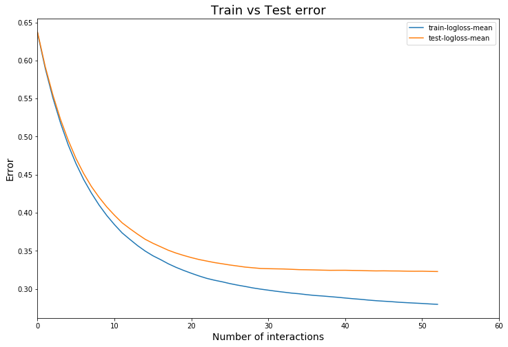

```python
# Error (log loss) vs number of interactions plot to verify proper algorithm implementation:

cvresult_plot=cvresult1[['train-logloss-mean', 'test-logloss-mean']].plot(figsize=(12, 8))
plt.title("Train vs Test error", fontsize=18)
plt.xlabel("Number of interactions", fontsize=14)
plt.ylabel("Error", fontsize=14)
plt.xlim(0,60)
```

**Conclusion:** From the chart above we can see that the log error is going low as a number of interactions increases, which indicates that the algorithm is implemented correctly (minimization of cost function defined). In addition on a specific point the CV error is starting to be greater compared to the train error which is actually represents an optimal minimum.

## 6) Confusion matrix and threshhold tuning

#### * Confusion matrix for (LFP prediction)

A confusion matrix is a table that is used to describe the performance of a classification model on a set of test data for which the true values are known.

Confusion matrix elements defenition:

- True Positives (TP): These are cases in which we predicted yes (participated).
- True Negatives (TN): We predicted no, and customers do not default.
- False Positives (FP): We predicted did not participated, but customers actually participated (" Type I error ").
- False Negatives (FN): We predicted participated, but customers actually did not participated (" Type II error ").

Let's plot the confusion matrix illustration the results of the Recall and Precision results

```python
def plot_confusion_matrix (cm, classes, title='Confusion matrix', cmap=plt.cm.GnBu):
    "The function prints and plots the confusion matrix"

    plt.imshow(cm, interpolation='nearest', cmap=cmap)
    plt.title(title)
    plt.colorbar()
    tick_marks = np.arange(len(classes))
    plt.xticks(tick_marks, classes)
    plt.yticks(tick_marks, classes)

    thresh = cm.max() / 2.
    for i, j in itertools.product(range(cm.shape[0]), range(cm.shape[1])):
        plt.text(j, i, cm[i, j],
                 horizontalalignment="center",
                 color="white" if cm[i, j] > thresh else "red")

    plt.tight_layout()
    plt.ylabel('True label')
    plt.xlabel('Predicted label')
```

```
From the total of 1536 the classifier predicted "Did not participated" 502 times and "Participated" 1034 times.

Compare to the true results, where 911 participated and 425 did not participated.
```

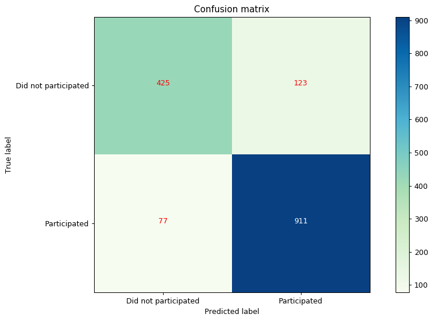

```python
# Print the confusion matrix of TP, FP, FN and TN values:
cnf_matrix = metrics.confusion_matrix(y_test, gbc_y_predict)
plt.figure(figsize=(10, 6), dpi=90)
plot_confusion_matrix(cnf_matrix, classes=['Did not participated', 'Participated'],
                      title='Confusion matrix')

cnf_matrix=pd.DataFrame(cnf_matrix)

print('From the total of', y_test.shape[0],'the classifier predicted "Did not participated"', cnf_matrix.iloc[:,0].sum(),
      'times and "Participated"',cnf_matrix.iloc[:,1].sum(),'times.\n')
print ('Compare to the true results, where', cnf_matrix.iloc[1,1], 'participated and', cnf_matrix.iloc[0,0],
       'did not participated.')
```

```python
# Printing precision and recall results vs various threshold levels:
gbc_y_pred_prob=gbc_y_pred_prob[:,1]
precision, recall, threshold = metrics.precision_recall_curve(y_test, gbc_y_pred_prob)
```

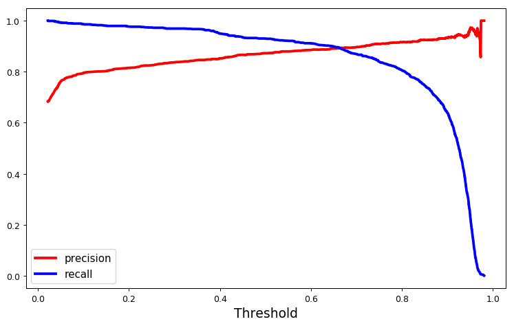

```python
def plot_precision_and_recall(precision, recall, threshold):
    "The function plots recall and precision for each threshold"

    plt.plot(threshold, precision[:-1], "r-", label="precision", linewidth=3)
    plt.plot(threshold, recall[:-1], "b", label="recall", linewidth=3)
    plt.xlabel("Threshold", fontsize=15 )
    plt.legend(loc="best",fontsize=12)

plt.figure(figsize=(10, 6), dpi=90)
plot_precision_and_recall(precision, recall, threshold)
```

We are now able to choose a threshold, that provides the best precision / recall tradeoff. We can easily look at the plots and see what threshold is needed to reach the required recall and precision levels. Then we can train a model with exactly that threshold and would get the desired results.

#### * ROC curve

The ROC curve is created by plotting the true positive rate (TPR) against the false positive rate (FPR) at various threshold settings. Each point on the ROC curve represents a sensitivity/specificity pair corresponding to a particular decision threshold. The area under the ROC curve (AUC) is a measure of how well a parameter can distinguish between two predicted classes.

```
Text(0.5,1,'ROC Curve')
```

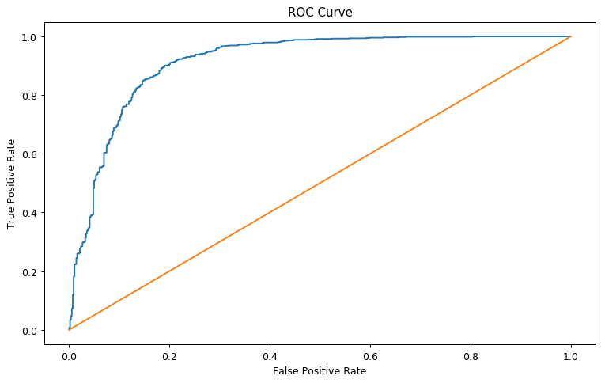

```python
# Plot the ROC curve based on the probability output of the model:
plt.figure(figsize=(10, 6), dpi=90)
fpr, tpr, thresholds = metrics.roc_curve(y_test, gbc_y_pred_prob)
plt.plot(fpr, tpr, label='ROC Curve ')
plt.plot([0, 1], [0, 1])
plt.xlabel('False Positive Rate')
plt.ylabel('True Positive Rate')
plt.title('ROC Curve')
```

## 7) Effort to improve the results-Stacking implementation

Stacking is an ensemble learning technique to combine multiple classification models via a meta-classifier. The individual classification models are trained based on the complete training set; then, the meta-classifier is fitted based on the outputs -- meta-features -- of the individual classification models in the ensemble. The meta-classifier can either be trained on the predicted class labels or probabilities from the ensemble

[figure not shown]

**Stacking - Step by step explanation:**

1. We train various machine learning algorithms (regressors or classifiers) in dataset A
2. We make predictions for each one of the algorithms for datasets B and C and we create new datasets B1 and C1 that contain only these predictions. So if we ran 10 models then B1 and C1 have 10 columns each.
3. We train a new machine learning algorithm (often referred to as Meta learner or Super learner) using B1
4. We make predictions using the Meta learner on C1

[figure not shown]

### 7.1) Stacking implementation for LFP prediction

```python
data, LFP=load_data_LFP()
```

```python
# Encoding categorical data - One Hot encoding:
cols = list(data.select_dtypes(include=['object']).columns)
data = pd.get_dummies(data=data, columns=cols,sparse=True)
data=data.fillna(999999) # Updated for random forest model
```

```python
# Spliting data to train and test for the model:
X_train, X_test, y_train, y_test = model_selection.train_test_split(data, LFP, test_size=test_size,random_state=seed)
```

```python
# Add a dictionary for fixed parameters.
params_1 = {
    'objective': 'binary:logistic',
    'silent': 2,
    'learning_rate': 0.1,
    'max_depth': 2,
    'n_estimators': 55

}

params_2 = {
    'objective': 'binary:logistic',
    'silent': 1,
    'learning_rate': 0.25,
    'max_depth': 3,
    'n_estimators': 75,
    'min_child_weight': 4
}

params_3 = {
    'objective': 'binary:logistic',
    'silent': 1,
    'learning_rate': 0.01,
    'max_depth': 7,
    'n_estimators': 85,
    'min_child_weight': 4,
    'colsample_bytree': 0.8,
    'subsample': 0.8
}


params_4 = {
    'objective': 'binary:logistic',
    'silent': 1,
    'learning_rate': 0.1,
    'max_depth': 3,
    'n_estimators': 50,
    'min_child_weight': 4,
    'colsample_bytree': 0.6,
    'gamma': 0.02,
}


meta_model1=xgb.XGBClassifier(**params_4, random_state=seed)
clf1 = xgb.XGBClassifier(**params_1, random_state=seed)
clf2 = xgb.XGBClassifier(**params_2, random_state=seed)
clf3 = xgb.XGBClassifier(**params_3, random_state=seed)
clf4 = ensemble.RandomForestClassifier(n_estimators=30,max_depth=2, min_samples_split=3,
                                       min_samples_leaf=2, random_state=seed)

sclf = StackingClassifier(classifiers=[clf3, clf2, clf1, clf4],
                          meta_classifier=meta_model1)
```

```python
model_stacked=sclf.fit(data,y)
```

```python
# Accuracy on cross validation:
print("One Hot Encoding - Accuracy on the cross validation is:",
round(np.mean(model_selection.cross_val_score(sclf, data, LFP, cv=skf, scoring='accuracy')),4))
```

```
One Hot Encoding - Accuracy on the cross validation is: 0.8724
```

```python
model_stacked=sclf.fit(X_train,y_train)
```

```python
# Accuracy on test data:
print("One Hot Encoding - Accuracy on the test data is:",
round(metrics.accuracy_score(y_test, model_stacked.predict(X_test)),2))
```

```
One Hot Encoding - Accuracy on the test data is: 0.9
```

```python
Results_summary=[('Without any categorical features', 0.8748),
                ('Using one hot encoding', 0.8756),
                ('Mean target encoding', 0.8748),
                ('Using Catboos library', 0.8704),
                ('Using 16 most import features', 0.8776),
                ('Manually tuned model', 0.9333),
                ('Stacked model', 0.9)]


Results_summary=pd.DataFrame(Results_summary, columns=['Various models and encoding technique', 'Accuracy score'])
Results_summary.sort_values('Accuracy score', ascending=False)
```

|  | Various models and encoding technique | Accuracy score |
| --- | --- | --- |
| 5 | Manually tuned model | 0.9333 |
| 6 | Stacked model | 0.9000 |
| 4 | Using 16 most import features | 0.8776 |
| 1 | Using one hot encoding | 0.8756 |
| 0 | Without any categorical features | 0.8748 |
| 2 | Mean target encoding | 0.8748 |
| 3 | Using Catboos library | 0.8704 |

**Conclusion**: According to the results above it was decided to choose the Manually tuned model as a final model for LFP prediction, as it accuracy result on the test data was the highest among all tested models.

### 7.2) Stacking implementation for IncomeUP

```python
data, YincomeUp=load_data_IncomeUp()
```

```python
# Encoding categorical data - One Hot encoding:
cols = list(data2.select_dtypes(include=['object']).columns)
X2 = pd.get_dummies(data=data2, columns=cols,sparse=True)
X2=X2.fillna(9999999) # Updated for random forest model
X3=X2.columns[X2.columns.duplicated()]
X2=X2.drop(X3,axis=1)
```

```python
# Spliting data to train and test for the model:
X_train, X_test, y_train, y_test = model_selection.train_test_split(data, YincomeUp, test_size=test_size,random_state=seed)
```

```python
# Add a dictionary for fixed parameters.
params_1 = {
    'objective': 'binary:logistic',
    'learning_rate': 0.1,
    'max_depth': 2,
    'n_estimators': 55

}

params_2 = {
    'objective': 'binary:logistic',
    'learning_rate': 0.25,
    'max_depth': 3,
    'n_estimators': 75,
    'min_child_weight': 3
}

params_3 = {
    'objective': 'binary:logistic',
    'learning_rate': 0.01,
    'max_depth': 7,
    'n_estimators': 100,
    'min_child_weight': 4,
    'colsample_bytree': 0.8,
    'subsample': 0.8,
    'lambda ':0.1
}

params_4 = {
    'objective': 'binary:logistic',
    'learning_rate': 0.01,
    'max_depth': 3,
    'n_estimators': 50,
    'min_child_weight': 4,
    'colsample_bytree': 0.6,
    'gamma': 0.0255
}


meta_model2=xgb.XGBClassifier(**params_4, random_state=seed)
clf1 = xgb.XGBClassifier(**params_1, random_state=seed)
clf2 = xgb.XGBClassifier(**params_2, random_state=seed)
clf3 = xgb.XGBClassifier(**params_3, random_state=seed)
clf4 = ensemble.RandomForestClassifier(n_estimators=40,max_depth=3, min_samples_split=3,
                                  min_samples_leaf=2, random_state=seed)

sclf = StackingClassifier(classifiers=[clf3, clf2, clf1, clf4],
                          meta_classifier=meta_model2)
```

```python
# Accuracy on cross validation:
print("One Hot Encoding - Accuracy on the cross validation is:",
round(np.mean(model_selection.cross_val_score(sclf, X_train, y_train, cv=skf, scoring='accuracy')),4))
```

```
One Hot Encoding - Accuracy on the cross validation is: 0.7908
```

```python
model_stacked=sclf.fit(X_train,y_train)
```

```python
# Accuracy on test data:
print("One Hot Encoding - Accuracy on the test data is:",
round(metrics.accuracy_score(y_test, model_stacked.predict(X_test)),2))
```

```
One Hot Encoding - Accuracy on the test data is: 0.87
```

```python
Results_summary_2=[('Without any categorical features', 0.7917),
                ('Using one hot encoding', 0.7962),
                ('Mean target encoding', 0.7995),
                ('Using Catboos library', 0.8105),
                ('Stacked model', 0.87)]


Results_summary_2=pd.DataFrame(Results_summary_2, columns=['Various models and encoding technique', 'Accuracy score'])
Results_summary_2.sort_values('Accuracy score', ascending=False)
```

|  | Various models and encoding technique | Accuracy score |
| --- | --- | --- |
| 4 | Stacked model | 0.8700 |
| 3 | Using Catboos library | 0.8105 |
| 2 | Mean target encoding | 0.7995 |
| 1 | Using one hot encoding | 0.7962 |
| 0 | Without any categorical features | 0.7917 |

### 7.3) Stacking implementation for Future Hour Income

```python
# Calling data_load function:
data, FuturehourIncome=load_data_hour_income()
```

```python
# Encoding categorical data - One Hot encoding:
cols = list(data3.select_dtypes(include=['object']).columns)
data = pd.get_dummies(data=data, columns=cols,sparse=True)
data=data.fillna(999999)
```

```python
# Spliting data to train and test for the model:
train_X, test_X, train_y, test_y = model_selection.train_test_split(data, FuturehourIncome, test_size=test_size,
                                                                    random_state=seed)
```

### 7.3.1) Base algorithms selected: 3 XGBOOST models

```python
# Checking each model individually - define algorithms:
gbm1 = XGBRegressor(max_depth=5, n_estimators=200, objective='reg:tweedie', subsample=0.4, colsample_bytree=0.6, random_state=seed)
gbm2 = XGBRegressor(max_depth=3, n_estimators=50, objective='reg:tweedie', random_state=seed)
gbm3 = XGBRegressor(max_depth=4, learning_rate=0.1, n_estimators=40, silent=True, objective='reg:tweedie',
                    gamma=1, min_child_weight=1, max_delta_step=0,
                    subsample=1, colsample_bytree=0.8, colsample_bylevel=0.6, reg_alpha=1, reg_lambda=1, scale_pos_weight=1,
                    random_state=0, seed=seed)
```

```python
models =[gbm1, gbm2, gbm3]
model_names=['gbm1', 'gbm2', 'gbm3']
```

```python
def predict_results(models, model_names, train_X, train_y):
    "The function predicts MSE results for each model on the test data and prints the results."

    for model, name in zip (models, model_names):
        model.fit(train_X, train_y)
        print('MSE score for',name, np.sqrt(metrics.mean_squared_error(test_y,model.predict(test_X))))
```

```python
predict_results(models, model_names, train_X, train_y)
```

```
MSE score for gbm1 38.456374750827614
MSE score for gbm2 36.736780976112954
MSE score for gbm3 37.89663645708056
```

```python
from sklearn.base import BaseEstimator, ClassifierMixin
class stacking_model (BaseEstimator, ClassifierMixin):

    def __init__(self, model, meta_model):
        self.model=model
        self.meta_model=meta_model
        self.n=len(model)
        self.valid=None

    def fit(self, X, y, p=0.3, cv=3, random_state=30):
        train_X, valid, train_y, y_valid = model_selection.train_test_split(X, y, test_size=p, random_state=30)

        if (p>0):
            self.valid=np.zeros((valid.shape[0], self.n))
            for i, model in enumerate(self.model):
                model.fit(train_X, train_y)
                self.valid[:,i]=model.predict(valid)

            self.meta_model.fit(self.valid, y_valid)

        else:
            self.valid = np.zeros((X.shape[0], self.n))
            for t, clf in enumerate(self.model):
                self.valid[:, t] += model_selection.cross_val_predict(clf, X, y, cv=cv,  method='predict', n_jobs=-1)
                clf.fit(X, y)
            self.meta_model.fit(self.valid, y)
        return self

    def predict(self, X, y=None):
        X_meta = np.zeros((X.shape[0], self.n))

        for t, clf in enumerate(self.model):
            X_meta[:, t] = clf.predict(X)

        results = self.meta_model.predict(X_meta)

        return (results)
```

```python
# Define a meta algorithm:
meta_model= Ridge()

# Train Meta model using a test split of 0.3:
stacked=stacking_model(models, meta_model)
stacked1=stacked.fit(train_X, train_y)
print('MSE score for stacked 1',np.sqrt(metrics.mean_squared_error(test_y,stacked1.predict(test_X))))

# Train Meta model using 5 folds:
stacked = stacking_model(models, meta_model)
stacked2=stacked.fit(train_X, train_y, p=-1)
print('MSE score for stacked 2',np.sqrt(metrics.mean_squared_error(test_y,stacked2.predict(test_X))))
```

```
MSE score for stacked 1 41.41087272094141
MSE score for stacked 2 36.26815789143364
```

**Mean results of models with a range of different train and test sizes:** The features for the Meta model are calculated by finding the mean of each base model prediction for a range of different train sizes.

```python
total = 0
train_sizes_results = []
blending_num=range(1,11)
p=[0.1, 0.2, 0.25, 0.3, 0.35, 0.4, 0.5, 0.55, 0.6, 0.65]
for i, stack_round in zip(p, blending_num):
    stacked.fit(train_X, train_y, i)
    total += stacked.predict(test_X, train_y)
    prop=total/stack_round
    MSE = np.sqrt(metrics.mean_squared_error(test_y, prop))
    print ('The result with train size of', i,'is:',  MSE)
    train_sizes_results.append(MSE)
```

```
The result with train size of 0.1 is: 36.25589175688652
The result with train size of 0.2 is: 36.12980362676896
The result with train size of 0.25 is: 36.09905287840967
The result with train size of 0.3 is: 36.47415836398809
The result with train size of 0.35 is: 36.73247015060485
The result with train size of 0.4 is: 37.09503754159595
The result with train size of 0.5 is: 37.25182371235972
The result with train size of 0.55 is: 37.29847562468268
The result with train size of 0.6 is: 37.24908143396675
The result with train size of 0.65 is: 37.23212558571271
```

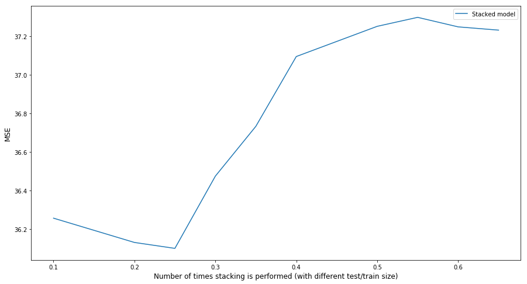

```python
# Ploting MSE score results for each trainqtest data split:
num_of_stacking=[0.1,0.2,0.25,0.3,0.35,0.4,0.5, 0.55,0.6,0.65]

plt.figure(figsize=(15, 8))
plt.plot(num_of_stacking, train_sizes_results, label='Stacked model')
plt.xlabel('Number of times stacking is performed (with different test/train size)', fontsize=12)
plt.ylabel('MSE',fontsize=12)
plt.legend()
```

**Conclusion**: We can see that the best MSE score result obtained once the test size proportion was 0.25. Additional splits are leading to overfitting.

### 7.3.2) Results of models with a range of different folds

1. Data is splited to train data and test data
2. Train data is seperated to X folds and each fold represent validation data
3. Each base model is trained on the half of train data (without validation folds)
4. Models predictions for each fold are concatenated to a new train data
5. Final predictions are calculated by training the meta model on the new train data and tested on the test data.

[figure not shown]

```python
s1 = stacking_model(models, meta_model)
total = 0
train_folds_results = []
for folds in range(2, 11):
    s1.fit(train_X, train_y, p=-1, cv=folds)
    total = s1.predict(test_X, train_y)
    MSE = np.sqrt(metrics.mean_squared_error(test_y, total))
    print ('The result with', t,'folds is:',  MSE)
    train_folds_results.append(MSE)
```

```
The result with 2 folds is: 36.361610720984885
The result with 3 folds is: 36.26815789143364
The result with 4 folds is: 36.65961436022171
The result with 5 folds is: 36.543676979250165
The result with 6 folds is: 36.72813891240093
The result with 7 folds is: 36.747861066450184
The result with 8 folds is: 36.59428365842797
The result with 9 folds is: 36.52598163143722
The result with 10 folds is: 36.67576411059213
```

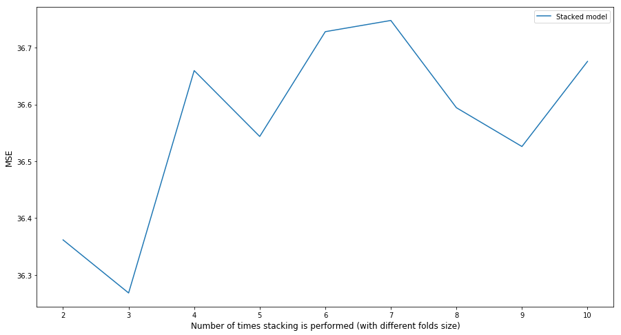

```python
# Ploting
x=range(2, 11)
plt.figure(figsize=(15, 8))
plt.plot(x, e1, label='Stacked model')
plt.xlabel('Number of times stacking is performed (with different folds size)', fontsize=12)
plt.ylabel('MSE',fontsize=12)
plt.legend()
```

**Conclusion**: We can see that the best MSE score result obtained using 3 folds.

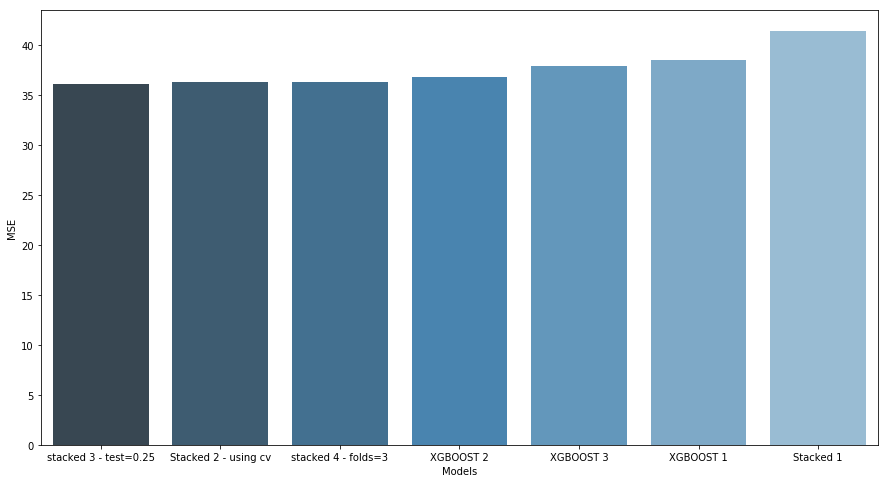

```python
# All models comparison:
results =[('XGBOOST 1', 38.456),
          ('XGBOOST 2', 36.737),
          ('XGBOOST 3', 37.897),
          ('Stacked 1', 41.411),
          ('Stacked 2 - using cv', 36.268),
          ('stacked 3 - test=0.25',36.099),
          ('stacked 4 - folds=3',36.268)]


results=pd.DataFrame(results, columns=['Models', 'MSE'])
results=results.sort_values('MSE')

plt.figure(figsize=(15,8))
sns.barplot(x=results['Models'], y=results['MSE'], palette="Blues_d")
```